# Week 6 - Review

Author

Emorie D Beck

[output not shown]

# Outline

1. Questions on Homework
2. `dplyr`
3. `tidyr`
4. Functions
5. `purrr`

# `dplyr`: `select()` and `filter()`

## 1. `select()`

### Add or remove using `select()` helper functions.

- `starts_with()`
- `ends_with()`
- `contains()`
- `matches()`
- `num_range()`
- `one_of()`
- `all_of()`

```r
bfi |>
  select(starts_with("C"))
```

|  | C1 | C2 | C3 | C4 | C5 |
| --- | --- | --- | --- | --- | --- |
| 61617 | 2 | 3 | 3 | 4 | 4 |
| 61618 | 5 | 4 | 4 | 3 | 4 |
| 61620 | 4 | 5 | 4 | 2 | 5 |
| 61621 | 4 | 4 | 3 | 5 | 5 |
| 61622 | 4 | 4 | 5 | 3 | 2 |
| 61623 | 6 | 6 | 6 | 1 | 3 |
| 61624 | 5 | 4 | 4 | 2 | 3 |
| 61629 | 3 | 2 | 4 | 2 | 4 |
| 61630 | 6 | 6 | 3 | 4 | 5 |
| 61633 | 6 | 5 | 6 | 2 | 1 |

[output cut: 2790 more lines]

## 2. `filter()`

- Often times, when conducting research (experiments or otherwise), there are observations (people, specific trials, etc.) that you don’t want to include.
- We can use `filter()` with logical statements to include only rows that match certain conditions
- We can refer to both bare quoted columns and objects in the global environment
  - `==` or `!=`
  - `<` or `<=`
  - `>` or `>=`
  - `%in%`
  - `all_of()`
  - `one_of()`
  - `!`
  - `|` and `&`

# tidyr: `pivot_longer()` and `pivot_wider()`

## 1. `pivot_longer()`

- (Formerly `gather()`) Makes wide data long, based on a key
- Core arguments:
  - `data`: the data, blank if piped
  - `cols`: columns to be made long, selected via `select()` calls
  - `names_to`: name(s) of key column(s) in new long data frame (string or string vector)
  - `values_to`: name of values in new long data frame (string)
  - `names_sep`: separator in column headers, if multiple keys
  - `values_drop_na`: drop missing cells (similar to `na.rm = T`)

### Why would I make my data longer?

- Main reason: Columns names sometimes contain data.
- Example: Billboard data has *time* information in column names

```r
data(billboard)
str(billboard)
```

```
spc_tbl_ [317 × 79] (S3: spec_tbl_df/tbl_df/tbl/data.frame)
 $ artist      : chr [1:317] "2 Pac" "2Ge+her" "3 Doors Down" "3 Doors Down" ...
 $ track       : chr [1:317] "Baby Don't Cry (Keep..." "The Hardest Part Of ..." "Kryptonite" "Loser" ...
 $ date.entered: Date[1:317], format: "2000-02-26" "2000-09-02" ...
 $ wk1         : num [1:317] 87 91 81 76 57 51 97 84 59 76 ...
 $ wk2         : num [1:317] 82 87 70 76 34 39 97 62 53 76 ...
 $ wk3         : num [1:317] 72 92 68 72 25 34 96 51 38 74 ...
 $ wk4         : num [1:317] 77 NA 67 69 17 26 95 41 28 69 ...
 $ wk5         : num [1:317] 87 NA 66 67 17 26 100 38 21 68 ...
 $ wk6         : num [1:317] 94 NA 57 65 31 19 NA 35 18 67 ...
 $ wk7         : num [1:317] 99 NA 54 55 36 2 NA 35 16 61 ...
 $ wk8         : num [1:317] NA NA 53 59 49 2 NA 38 14 58 ...
 $ wk9         : num [1:317] NA NA 51 62 53 3 NA 38 12 57 ...
 $ wk10        : num [1:317] NA NA 51 61 57 6 NA 36 10 59 ...
 $ wk11        : num [1:317] NA NA 51 61 64 7 NA 37 9 66 ...
 $ wk12        : num [1:317] NA NA 51 59 70 22 NA 37 8 68 ...
 $ wk13        : num [1:317] NA NA 47 61 75 29 NA 38 6 61 ...
 $ wk14        : num [1:317] NA NA 44 66 76 36 NA 49 1 67 ...
 $ wk15        : num [1:317] NA NA 38 72 78 47 NA 61 2 59 ...
 $ wk16        : num [1:317] NA NA 28 76 85 67 NA 63 2 63 ...
 $ wk17        : num [1:317] NA NA 22 75 92 66 NA 62 2 67 ...
 $ wk18        : num [1:317] NA NA 18 67 96 84 NA 67 2 71 ...
 $ wk19        : num [1:317] NA NA 18 73 NA 93 NA 83 3 79 ...
 $ wk20        : num [1:317] NA NA 14 70 NA 94 NA 86 4 89 ...
 $ wk21        : num [1:317] NA NA 12 NA NA NA NA NA 5 NA ...
 $ wk22        : num [1:317] NA NA 7 NA NA NA NA NA 5 NA ...
 $ wk23        : num [1:317] NA NA 6 NA NA NA NA NA 6 NA ...
 $ wk24        : num [1:317] NA NA 6 NA NA NA NA NA 9 NA ...
 $ wk25        : num [1:317] NA NA 6 NA NA NA NA NA 13 NA ...
 $ wk26        : num [1:317] NA NA 5 NA NA NA NA NA 14 NA ...
 $ wk27        : num [1:317] NA NA 5 NA NA NA NA NA 16 NA ...
 $ wk28        : num [1:317] NA NA 4 NA NA NA NA NA 23 NA ...
 $ wk29        : num [1:317] NA NA 4 NA NA NA NA NA 22 NA ...
 $ wk30        : num [1:317] NA NA 4 NA NA NA NA NA 33 NA ...
 $ wk31        : num [1:317] NA NA 4 NA NA NA NA NA 36 NA ...
 $ wk32        : num [1:317] NA NA 3 NA NA NA NA NA 43 NA ...
 $ wk33        : num [1:317] NA NA 3 NA NA NA NA NA NA NA ...
 $ wk34        : num [1:317] NA NA 3 NA NA NA NA NA NA NA ...
 $ wk35        : num [1:317] NA NA 4 NA NA NA NA NA NA NA ...
 $ wk36        : num [1:317] NA NA 5 NA NA NA NA NA NA NA ...
```

[output cut: 109 more lines]

```
  ..   wk63 = col_double(),
  ..   wk64 = col_double(),
  ..   wk65 = col_double(),
  ..   wk66 = col_logical(),
  ..   wk67 = col_logical(),
  ..   wk68 = col_logical(),
  ..   wk69 = col_logical(),
  ..   wk70 = col_logical(),
  ..   wk71 = col_logical(),
  ..   wk72 = col_logical(),
  ..   wk73 = col_logical(),
  ..   wk74 = col_logical(),
  ..   wk75 = col_logical(),
  ..   wk76 = col_logical()
  .. )
```

```r
billboard |>
  pivot_longer(
    cols = starts_with("wk"),
    names_to = "week",
    names_prefix = "wk",
    names_transform = as.numeric,
    values_to = "rank"
  )
```

| artist | track | date.entered | week | rank |
| --- | --- | --- | --- | --- |
| 2 Pac | Baby Don't Cry (Keep... | 2000-02-26 | 1 | 87 |
| 2 Pac | Baby Don't Cry (Keep... | 2000-02-26 | 2 | 82 |
| 2 Pac | Baby Don't Cry (Keep... | 2000-02-26 | 3 | 72 |
| 2 Pac | Baby Don't Cry (Keep... | 2000-02-26 | 4 | 77 |
| 2 Pac | Baby Don't Cry (Keep... | 2000-02-26 | 5 | 87 |
| 2 Pac | Baby Don't Cry (Keep... | 2000-02-26 | 6 | 94 |
| 2 Pac | Baby Don't Cry (Keep... | 2000-02-26 | 7 | 99 |
| 2 Pac | Baby Don't Cry (Keep... | 2000-02-26 | 8 | NA |
| 2 Pac | Baby Don't Cry (Keep... | 2000-02-26 | 9 | NA |
| 2 Pac | Baby Don't Cry (Keep... | 2000-02-26 | 10 | NA |

[output cut: 9990 more lines]

- This doesn’t just apply to longitudinal data. This is also important when thinking about iteration.
- For example, if you variables can be grouped into different categories (covariates, IVs/predictors, DVs/outcomes, moderators, etc.), then your column names contain *implicit* data
- The data below contain *both* time, variable, and category information

```r
# load the codebook
(codebook <- read_csv("week6-codebook.csv") |>
    mutate(old_name = str_to_lower(old_name)))
```

| dataset | old_name | item_text | scale | category | label | item_name | year | new_name | reverse | mini | maxi | recode | lavaan_name |
| --- | --- | --- | --- | --- | --- | --- | --- | --- | --- | --- | --- | --- | --- |
| NA | persnr | Never Changing Person ID | NA | Procedural | NA | SID | 0 | Proc_SID | 1 | NA | NA | NA | NA |
| NA | hhnr | household ID | NA | Procedural | NA | household | 0 | Proc_HHID | 1 | NA | NA | NA | NA |
| ppfad | gebjahr | Year of Birth | numeric | Demographic | NA | DOB | 0 | Demo_dob | 1 | NA | NA | NA | NA |
| ppfad | sex | Sex | \n1 [1] Male\n2 [2] Female\n-1 [-1] No Answer\n-2 [-2] Does not apply\n-3 [-3] Answer improbable\n-4 [-4] Inadmissible multiple response\n-5 [-5] Not included in this version of the questionnaire\n-6 … | Demographic | NA | Sex | 0 | Demo__sex | 1 | NA | NA | NA | NA |
| vp | vp12501 | Thorough Worker | NA | big5 | C | thorough | 2005 | big5_C_thorough_2005 | 1 | 1 | 7 | NA | I1 |
| zp | zp12001 | Thorough Worker | NA | big5 | C | thorough | 2006 | big5_C_thorough_2006 | 1 | 1 | 7 | NA | I1 |
| bdp | bdp15101 | Thorough Worker | NA | big5 | C | thorough | 2013 | big5_C_thorough_2013 | 1 | 1 | 7 | NA | I1 |
| vp | vp12502 | Am communicative | NA | big5 | E | communic | 2005 | big5_E_communic_2005 | 1 | 1 | 7 | NA | I1 |
| zp | zp12002 | Am communicative | NA | big5 | E | communic | 2009 | big5_E_communic_2009 | 1 | 1 | 7 | NA | I1 |
| bdp | bdp15102 | Am communicative | NA | big5 | E | communic | 2013 | big5_E_communic_2013 | 1 | 1 | 7 | NA | I1 |

[output cut: 143 more lines]

```r
old.names <- codebook$old_name # get old column names
new.names <- codebook$new_name # get new column names
soep <- read_csv("week6-data.csv") |>
    select(all_of(old.names))
```

### Exercise

- By pivoting our data longer, we can more easily extract information from the column names
- Pivot the data below longer. Some hints:
  - don’t make the procedural or demographic variables long
  - split the column names you make long into four chunks:
    - “category”, “label”, “item_name”, “year”
  - drop `NA` values

Solution:

```r
soep_long <- soep |>
  setNames(new.names) |>
  pivot_longer(
    cols = c(-starts_with("Proc"), -starts_with("Dem"))
    , names_to = c("category",  "label",    "item_name",    "year")
    , names_pattern = "(.*)_(.*)_(.*)_(.*)"
    , values_to = "value"
    , values_drop_na = T
  ) |> mutate(year = as.numeric(year))
soep_long
```

| Proc_SID | Proc_HHID | Demo_dob | Demo__sex | category | label | item_name | year | value |
| --- | --- | --- | --- | --- | --- | --- | --- | --- |
| 901 | 94 | 1951 | 2 | big5 | C | thorough | 2005 | 6 |
| 901 | 94 | 1951 | 2 | big5 | C | thorough | 2006 | -1 |
| 901 | 94 | 1951 | 2 | big5 | C | thorough | 2013 | 7 |
| 901 | 94 | 1951 | 2 | big5 | E | communic | 2005 | 4 |
| 901 | 94 | 1951 | 2 | big5 | E | communic | 2009 | 4 |
| 901 | 94 | 1951 | 2 | big5 | E | communic | 2013 | 5 |
| 901 | 94 | 1951 | 2 | big5 | A | coarse | 2005 | 4 |
| 901 | 94 | 1951 | 2 | big5 | A | coarse | 2009 | 3 |
| 901 | 94 | 1951 | 2 | big5 | A | coarse | 2013 | 4 |
| 901 | 94 | 1951 | 2 | big5 | O | original | 2005 | 5 |

[output cut: 9990 more lines]

- Long format data are easier to clean (we’ll come back to this but we’ll create the cleaned data frame to use for merging practice)

```r
soep_big5 <- soep_long |>
  filter(category == "big5") |>
  mutate(value = mapvalues(value, seq(-8,0), rep(NA, 9))) |>
  drop_na(value) |>
  group_by(Proc_SID, label, year) |>
  summarize(value = mean(value)) |>
  ungroup()

soep_le <- soep_long |>
  filter(category == "le") |>
  mutate(value = mapvalues(value, seq(-8,1), c(rep(NA, 6), 0, NA, NA, 1))) |>
  drop_na(value) |>
  group_by(Proc_SID, label) |>
  summarize(value = sum(value)) |>
  ungroup()

soep_clean <- soep_big5 |>
  rename(trait = label, p_value = value) |>
  inner_join(
    soep_le |>
      rename(le = label, le_value = value)
  )
```

## 2. `pivot_wider()`

- (Formerly `spread()`) Makes wide data long, based on a key
- Core arguments:
  - `data`: the data, blank if piped
  - `names_from`: name(s) of key column(s) in new long data frame (string or string vector)
  - `names_sep`: separator in column headers, if multiple keys
  - `names_glue`: specify multiple or custom separators of multiple keys
  - `values_from`: name of values in new long data frame (string)
  - `values_fn`: function applied to data with duplicate labels

### Why would I pivot wider?

- Some analyses require wide format data
- For example, SEM in `lavaan` in R requires that both indicators and time are wide format.
- The code below uses the codebook to rename items according to a numbered format that isn’t specific to any trait

```r
big5 <- codebook |> filter(category == "big5")
soep_lavaan <- soep_long |>
  filter(category == "big5") |>
  mutate(item_name = mapvalues(item_name, big5$item_name, big5$lavaan_name, warn_missing = F))
soep_lavaan
```

| Proc_SID | Proc_HHID | Demo_dob | Demo__sex | category | label | item_name | year | value |
| --- | --- | --- | --- | --- | --- | --- | --- | --- |
| 901 | 94 | 1951 | 2 | big5 | C | I1 | 2005 | 6 |
| 901 | 94 | 1951 | 2 | big5 | C | I1 | 2006 | -1 |
| 901 | 94 | 1951 | 2 | big5 | C | I1 | 2013 | 7 |
| 901 | 94 | 1951 | 2 | big5 | E | I1 | 2005 | 4 |
| 901 | 94 | 1951 | 2 | big5 | E | I1 | 2009 | 4 |
| 901 | 94 | 1951 | 2 | big5 | E | I1 | 2013 | 5 |
| 901 | 94 | 1951 | 2 | big5 | A | I1 | 2005 | 4 |
| 901 | 94 | 1951 | 2 | big5 | A | I1 | 2009 | 3 |
| 901 | 94 | 1951 | 2 | big5 | A | I1 | 2013 | 4 |
| 901 | 94 | 1951 | 2 | big5 | O | I1 | 2005 | 5 |

[output cut: 9990 more lines]

### Exercise

- Change the `soep_lavaan` data frame to be in wide format using `pivot_wider()`:
  - pull the `names` from two sources: `item_name()` and `year`

```r
soep_lavaan |>
  pivot_wider(
    names_from = c("item_name", "year")
    , values_from = "value"
  )
```

| Proc_SID | Proc_HHID | Demo_dob | Demo__sex | category | label | I1_2005 | I1_2006 | I1_2013 | I1_2009 | I2_2005 | I2_2009 | I2_2013 | I3_2005 | I3_2009 | I3_2013 |
| --- | --- | --- | --- | --- | --- | --- | --- | --- | --- | --- | --- | --- | --- | --- | --- |
| 901 | 94 | 1951 | 2 | big5 | C | 6 | -1 | 7 | NA | 4 | 4 | 3 | 5 | 6 | 5 |
| 901 | 94 | 1951 | 2 | big5 | E | 4 | NA | 5 | 4 | 5 | 5 | 4 | 6 | 6 | 6 |
| 901 | 94 | 1951 | 2 | big5 | A | 4 | NA | 4 | 3 | 5 | 5 | 4 | 5 | 5 | 6 |
| 901 | 94 | 1951 | 2 | big5 | O | 5 | NA | 3 | 4 | 3 | 4 | 3 | 4 | 4 | 4 |
| 901 | 94 | 1951 | 2 | big5 | N | 6 | NA | 6 | 6 | 3 | 5 | 2 | 3 | 3 | 5 |
| 1202 | 124 | 1913 | 2 | big5 | C | 7 | NA | NA | NA | 1 | NA | NA | 4 | NA | NA |
| 1202 | 124 | 1913 | 2 | big5 | E | 6 | NA | NA | NA | 7 | NA | NA | 7 | NA | NA |
| 1202 | 124 | 1913 | 2 | big5 | A | 1 | NA | NA | NA | -1 | NA | NA | 7 | NA | NA |
| 1202 | 124 | 1913 | 2 | big5 | O | 6 | NA | NA | NA | 5 | NA | NA | 6 | NA | NA |
| 1202 | 124 | 1913 | 2 | big5 | N | 6 | NA | NA | NA | 6 | NA | NA | 3 | NA | NA |

[output cut: 9990 more lines]

# `dplyr`: `_join()’

## The `_join()` Functions

- Often we may need to pull different data from different sources
- There are lots of reasons to need to do this
- We don’t have time to get into all the use cases here, so we’ll talk about them in high level terms
- We’ll focus on:
  - `full_join()`
  - `inner_join()`
  - `left_join()`
  - `right_join()`

## 3. `full_join()`

- Most simply, we can put those back together keeping all observations.
- Pro: sometimes we want to maintain missing data (i.e. some people are randomly missing variables and we don’t want to drop them completely)
- Con: can leave you with lots of `NA`s
- Join the codebook to the data below using `full_join()`
- Look at the data. What’s going on here

```r
soep_long |>
  filter(!category == "big5")
  full_join(
    # your code here
  ) |>
    View()
```

Here’s the solution:

```r
soep_long |>
  filter(!category == "big5") |>
  full_join(codebook |> select(category, label, item_name, year, item_text))
```

| Proc_SID | Proc_HHID | Demo_dob | Demo__sex | category | label | item_name | year | value | item_text |
| --- | --- | --- | --- | --- | --- | --- | --- | --- | --- |
| 901 | 94 | 1951 | 2 | le | ChldBrth | ChldBrth | 2005 | -2 | Child Born |
| 901 | 94 | 1951 | 2 | le | ChldBrth | ChldBrth | 2006 | -2 | Child Born |
| 901 | 94 | 1951 | 2 | le | ChldBrth | ChldBrth | 2007 | -2 | Child Born |
| 901 | 94 | 1951 | 2 | le | ChldBrth | ChldBrth | 2008 | -2 | Child Born |
| 901 | 94 | 1951 | 2 | le | ChldBrth | ChldBrth | 2009 | -2 | Child Born |
| 901 | 94 | 1951 | 2 | le | ChldBrth | ChldBrth | 2010 | -2 | Child Born |
| 901 | 94 | 1951 | 2 | le | ChldBrth | ChldBrth | 2011 | -2 | Child Born |
| 901 | 94 | 1951 | 2 | le | ChldBrth | ChldBrth | 2012 | -2 | Child Born |
| 901 | 94 | 1951 | 2 | le | ChldBrth | ChldBrth | 2013 | -2 | Child Born |
| 901 | 94 | 1951 | 2 | le | ChldBrth | ChldBrth | 2014 | -2 | Child Born |

[output cut: 9990 more lines]

- note we have lots of missing data because the Big Five portions of the codebook were joined even though we removed that data

## 4. `inner_join()`

- We can also keep all rows present in *both* data frames
- Pro: Won’t add rows with missing values in key variables
- Con: will drop observations that you want want for counts, correlations, etc.
- Join the codebook to the data below using `inner_join()`
- Look at the data. What’s going on here

```r
soep_long |>
  filter(!category == "big5")
  full_join(
    # your code here
  ) |>
    View()
```

- Note that filtering, renaming/selecting, and joining is a common workflow

```r
soep_long |>
  filter(category == "big5") |>
  select(Proc_SID, trait = label, item_name, year, p_value = value) |>
  inner_join(
    soep_long |>
    filter(category == "le") |>
    select(Proc_SID, le = label, year, le_value = value)
  )
```

| Proc_SID | trait | item_name | year | p_value | le | le_value |
| --- | --- | --- | --- | --- | --- | --- |
| 901 | C | thorough | 2005 | 6 | ChldBrth | -2 |
| 901 | C | thorough | 2005 | 6 | ChldMvOut | -2 |
| 901 | C | thorough | 2005 | 6 | Divorce | -2 |
| 901 | C | thorough | 2005 | 6 | DadDied | -2 |
| 901 | C | thorough | 2005 | 6 | Married | -2 |
| 901 | C | thorough | 2005 | 6 | MomDied | -2 |
| 901 | C | thorough | 2005 | 6 | MoveIn | -2 |
| 901 | C | thorough | 2005 | 6 | PartDied | -2 |
| 901 | C | thorough | 2005 | 6 | SepPart | -2 |
| 901 | C | thorough | 2006 | -1 | ChldBrth | -2 |

[output cut: 9990 more lines]

## 5. `left_join()`

- Or all rows present in the left (first) data frame, perhaps if it’s a subset of people with complete data

```r
soep_long |>
  filter(category == "big5") |>
  select(Proc_SID, trait = label, item_name, year, p_value = value) |>
  left_join(
    soep_long |>
    filter(category == "le") |>
    select(Proc_SID, le = label, year, le_value = value)
  )
```

| Proc_SID | trait | item_name | year | p_value | le | le_value |
| --- | --- | --- | --- | --- | --- | --- |
| 901 | C | thorough | 2005 | 6 | ChldBrth | -2 |
| 901 | C | thorough | 2005 | 6 | ChldMvOut | -2 |
| 901 | C | thorough | 2005 | 6 | Divorce | -2 |
| 901 | C | thorough | 2005 | 6 | DadDied | -2 |
| 901 | C | thorough | 2005 | 6 | Married | -2 |
| 901 | C | thorough | 2005 | 6 | MomDied | -2 |
| 901 | C | thorough | 2005 | 6 | MoveIn | -2 |
| 901 | C | thorough | 2005 | 6 | PartDied | -2 |
| 901 | C | thorough | 2005 | 6 | SepPart | -2 |
| 901 | C | thorough | 2006 | -1 | ChldBrth | -2 |

[output cut: 9990 more lines]

## 6. `right_join()`

- Or all rows present in the right (second) data frame, such as I do when I join a codebook with raw data

```r
soep_long |>
  filter(category == "big5") |>
  select(Proc_SID, trait = label, item_name, year, p_value = value) |>
  right_join(
    soep_long |>
    filter(category == "le") |>
    select(Proc_SID, le = label, year, le_value = value)
  )
```

| Proc_SID | trait | item_name | year | p_value | le | le_value |
| --- | --- | --- | --- | --- | --- | --- |
| 901 | C | thorough | 2005 | 6 | ChldBrth | -2 |
| 901 | C | thorough | 2005 | 6 | ChldMvOut | -2 |
| 901 | C | thorough | 2005 | 6 | Divorce | -2 |
| 901 | C | thorough | 2005 | 6 | DadDied | -2 |
| 901 | C | thorough | 2005 | 6 | Married | -2 |
| 901 | C | thorough | 2005 | 6 | MomDied | -2 |
| 901 | C | thorough | 2005 | 6 | MoveIn | -2 |
| 901 | C | thorough | 2005 | 6 | PartDied | -2 |
| 901 | C | thorough | 2005 | 6 | SepPart | -2 |
| 901 | C | thorough | 2006 | -1 | ChldBrth | -2 |

[output cut: 9990 more lines]

## Your Turn

In small groups, discuss what’s happening when you use `full_join()`, `left_join()`, `right_join()`, `inner_join()`, and `anti_join()` with the code below. Which is correct in this use case?

```r
soep_long |>
  filter(category == "big5") |>
  select(Proc_SID, trait = label, item_name, year, p_value = value) |>
  [x]_join(
    soep_long |>
    filter(category == "le") |>
    select(Proc_SID, le = label, year, le_value = value)
  )
```

# `dplyr`: split-apply-combine

## Bringing it all together: Split-Apply-Combine

- Much of the power of `dplyr` functions lay in the split-apply-combine method
- A given set of of data are:
  - *split* into smaller chunks
  - then a function or series of functions are *applied* to each chunk
  - and then the chunks are *combined* back together

## 3. `group_by()`

- The `group_by()` function is the “split” of the method
- It basically implicitly breaks the data set into chunks by whatever bare quoted column(s)/variable(s) are supplied as arguments.

## 4. `mutate()`

- `mutate()` is one of your “apply” functions
- When you use `mutate()`, the resulting data frame will have the same number of rows you started with
- You are directly mutating the existing data frame, either modifying existing columns or creating new ones

## 5. `summarize()` / `summarise()`

- `summarize()` is one of your “apply” functions
- The resulting data frame will have the same number of rows as your grouping variable
- You number of groups is 1 for ungrouped data frames

# Exercise 1

- Remember when I said that long format data are easier to clean. Let’s do that now.

## Question 1:

- Let’s start with the Big Five data:
1. `filter()` out only Big Five rows
2. `mutate()` each observation so that values less than one are changed to `NA`
3. Remove any missing values using `filter()` or `drop_na()`
4. Group (split) the data so that you have a “group” for each person x trait x year combination
5. `summarize()` the values to get a composite score for each Big Five trait for each person in each year:

### Solution

Remember when I said that long format data are easier to clean. Let’s do that now.

```r
soep_big5 <- soep_long |>
  filter(category == "big5") |>
  mutate(value = mapvalues(value, seq(-8,0), rep(NA, 9))) |>
  drop_na(value) |>
  group_by(Proc_SID, label, year) |>
  summarize(value = mean(value)) |>
  ungroup()
soep_big5
```

| Proc_SID | label | year | value |
| --- | --- | --- | --- |
| 901 | A | 2005 | 4.666667 |
| 901 | A | 2009 | 4.333333 |
| 901 | A | 2013 | 4.666667 |
| 901 | C | 2005 | 5.000000 |
| 901 | C | 2009 | 5.000000 |
| 901 | C | 2013 | 5.000000 |
| 901 | E | 2005 | 5.000000 |
| 901 | E | 2009 | 5.000000 |
| 901 | E | 2013 | 5.000000 |
| 901 | N | 2005 | 4.000000 |

[output cut: 9990 more lines]

## Question 2:

Now let’s take care of the life event data:  
1. `filter()` out only life event rows  
2. `mutate()` each observation so that

- -2 = 0
- 1 = 1
- everything else is `NA`
3. Remove any missing values using `filter()` or `drop_na()`
4. Group (split) the data so that you have a “group” for each person x event combination
5. `summarize()` the values to get a `sum` score for each event for each person across all years:

### Solution

```r
soep_le <- soep_long |>
  filter(category == "le") |>
  mutate(value = mapvalues(value, seq(-8,1), c(rep(NA, 6), 0, NA, NA, 1))) |>
  drop_na(value) |>
  group_by(Proc_SID, label) |>
  summarize(value = sum(value)) |>
  ungroup()
soep_le
```

| Proc_SID | label | value |
| --- | --- | --- |
| 901 | ChldBrth | 0 |
| 901 | ChldMvOut | 0 |
| 901 | DadDied | 0 |
| 901 | Divorce | 0 |
| 901 | Married | 0 |
| 901 | MomDied | 2 |
| 901 | MoveIn | 0 |
| 901 | NewPart | 0 |
| 901 | PartDied | 0 |
| 901 | SepPart | 0 |

[output cut: 9990 more lines]

## Question 3:

Just for practice, now make your Big Five data frame wide, leaving the time variable (year) long

### Solution

```r
soep_big5 |>
  pivot_wider(
    names_from = "label"
    , values_from = "value"
  )
```

| Proc_SID | year | A | C | E | N | O |
| --- | --- | --- | --- | --- | --- | --- |
| 901 | 2005 | 4.666667 | 5.000000 | 5.000000 | 4.000000 | 4.000000 |
| 901 | 2009 | 4.333333 | 5.000000 | 5.000000 | 4.666667 | 4.000000 |
| 901 | 2013 | 4.666667 | 5.000000 | 5.000000 | 4.333333 | 3.333333 |
| 1202 | 2005 | 4.000000 | 4.000000 | 6.666667 | 5.000000 | 5.666667 |
| 2301 | 2005 | 5.666667 | 5.666667 | 5.000000 | 4.333333 | 4.333333 |
| 2301 | 2009 | 5.666667 | 4.500000 | 4.000000 | 5.333333 | 5.000000 |
| 2301 | 2013 | 4.666667 | 5.333333 | 5.333333 | 3.666667 | 5.000000 |
| 2301 | 2006 | NA | 6.000000 | NA | NA | NA |
| 2302 | 2005 | 4.666667 | 4.666667 | 4.666667 | 3.666667 | 5.000000 |
| 2302 | 2009 | 4.000000 | 5.500000 | 5.333333 | 3.000000 | 4.333333 |

[output cut: 9990 more lines]

## Question 4:

- Now, let’s join the data frames back together.
- Which join function do you think is most appropriate?
- Hint: You will need to rename the `label` and `value` columns to reflect the category of the data

### Solution

```r
soep_clean <- soep_big5 |>
  rename(trait = label, p_value = value) |>
  inner_join(
    soep_le |>
      rename(le = label, le_value = value)
  )
soep_clean
```

| Proc_SID | trait | year | p_value | le | le_value |
| --- | --- | --- | --- | --- | --- |
| 901 | A | 2005 | 4.666667 | ChldBrth | 0 |
| 901 | A | 2005 | 4.666667 | ChldMvOut | 0 |
| 901 | A | 2005 | 4.666667 | DadDied | 0 |
| 901 | A | 2005 | 4.666667 | Divorce | 0 |
| 901 | A | 2005 | 4.666667 | Married | 0 |
| 901 | A | 2005 | 4.666667 | MomDied | 2 |
| 901 | A | 2005 | 4.666667 | MoveIn | 0 |
| 901 | A | 2005 | 4.666667 | NewPart | 0 |
| 901 | A | 2005 | 4.666667 | PartDied | 0 |
| 901 | A | 2005 | 4.666667 | SepPart | 0 |

[output cut: 9990 more lines]

# Functions

## Functions

**How to approach writing functions**? (*broad recipe*)

1. Experiment with performing the task outside of a function
   - Experiment with performing task with different sets of inputs
   - Often, you must revise this code, when an approach that worked outside a function does not work within a function
2. Write the function
3. Test the function
   - Try to “break” it
4. **Continual improvement**. As you use the function, make continual improvements going back-and-forth between steps 1-3

## Basics of writing functions

**Three components** of a function:

1. **Function name**
   - Define a function using `function()` and give it a **name** using the assignment operator `<-`
2. **Function arguments** (sometimes called “inputs”)
   - Inputs that the function takes; they go inside the parentheses of `function()`
     - Can be vectors, data frames, logical statements, strings, etc.
   - In the above hypothetical code, the function took three inputs `arg1`, `arg2`, `arg3`, but we could have written:
     - `function(x, y, z)` or `function(Larry, Curly, Moe)`
   - In the “function call,” you specify values to assign to these function arguments
3. **Function body**
   - What the function does to the inputs
   - Function body goes inside the pair of curly brackets (`{}`) that follows `function()`
   - Above hypothetical function doesn’t do anything, but your function can **return a value** (covered in later section)

# Exercise 2

Some common tasks when working with survey data:

- Identify number of observations with `NA` values for a specific variable
- Identify number of observations with negative values for a specific variable
- Replace negative values with `NA` for a specific variable

## `num_negative()` function

**Task**: Write function called `num_negative()`

- Write a function that counts the number of observations with negative values for a specific variable
- Apply this function to variables from dataframe `df` (created below)
- Adapted from Ben Skinner’s *Programming 1* R Workshop [HERE](https://www.btskinner.me/rworkshop/modules/programming_one.html)

```r
# Sample dataframe `df` that contains some negative values
df
```

| id | age | sibage | parage |
| --- | --- | --- | --- |
| 1 | 17 | 8 | 49 |
| 2 | 15 | -97 | 46 |
| 3 | -97 | -97 | 53 |
| 4 | 13 | 12 | -4 |
| 5 | -97 | 10 | 47 |
| 6 | 12 | 10 | 52 |
| 7 | -99 | 5 | 51 |
| 8 | -97 | 10 | 55 |
| 9 | 16 | 6 | 51 |
| 10 | 16 | -99 | -8 |

[output cut: 90 more lines]

## Steps:

**Recommended steps**:

- Perform task outside of function
  - HINT: `sum(data_frame_name$var_name<0)`
- Write function
- Apply/test function on variables

### Step 1: Perform task outside of function

```r
names(df) # identify variable names
```

```
[1] "id"     "age"    "sibage" "parage"
```

```r
df$age # print observations for a variable
```

```
  [1]  17  15 -97  13 -97  12 -99 -97  16  16 -98  20 -99  20  11  20  12  17
 [19]  19  17 -97 -99  12  13  11  15  20  14 -99  11  20 -98  11 -98  12  16
 [37]  12  18  12  19  12 -97  20  17  11  19  19  12 -98  11  15  18  15 -98
 [55]  15  19 -97  13 -98  16  13  12  16  19 -99  19 -98  13 -97  20  15  19
 [73]  15  12  18 -99  18 -98 -98 -98 -97  12  14  19 -97  11  20  18  14 -99
 [91]  15  20 -97  14  14  19  18  17  20  15
```

```r
#BaseR
sum(df$age<0) # count number of obs w/ negative values for variable "age"
```

```
[1] 27
```

### Step 2: Write function

```r
num_missing <- function(x){
  sum(x<0)
}
```

### Step 3: Apply function

```r
num_missing(df$age)
```

```
[1] 27
```

```r
num_missing(df$sibage)
```

```
[1] 22
```

# Exercise 3:

In survey data, negative values often refer to reason for missing values:

- E.g., `-8` refers to “didn’t take survey”
- E.g., `-7` refers to “took survey, but didn’t answer this question”

## `num_missing()` function

**Task**: Write function called `num_negative()`

- Write a function that counts number of missing observations for a variable and allows you to specify which values are associated with missing for that variable. This function will take two arguments:
  - `x`: The variable (e.g., `df$sibage`)
  - `miss_vals`: Vector of values you want to associate with “missing” variable
    - Values to associate with missing for `df$age`: `-97,-98,-99`
    - Values to associate with missing for `df$sibage`: `-97,-98,-99`
    - Values to associate with missing for `df$parage`: `-4,-7,-8`

## Steps

**Recommended steps**:

- Perform task outside of function
  - HINT: `sum(data_frame_name$var_name %in% c(-4,-5))`
- Write function
- Apply/test function on variables

### Step 1: Perform task outside of function

```r
sum(df$age %in% c(-97,-98,-99))
```

```
[1] 27
```

### Step 2: Write function

```r
num_missing <- function(x, miss_vals){

  sum(x %in% miss_vals)
}
```

### Step 3: Apply function

```r
num_missing(df$age,c(-97,-98,-99))
```

```
[1] 27
```

```r
num_missing(df$sibage,c(-97,-98,-99))
```

```
[1] 22
```

```r
num_missing(df$parage,c(-4,-7,-8))
```

```
[1] 17
```

# `purrr`

## purrr::`map()`

- `map()` functions are the tidyverse alternative to for loops and chaotic lists with deep nesting structures
- `map()` functions, unlike `_apply()` functions can take any number of inputs, which mimics nested `for` loops
- `map()` functions can return any output type, including heterogeneous outputs (at least if you return it as a list)
- You control how many inputs using the following:
  - `map()`: one input, arguments are `map(.x, .f)`
  - `map2()`: two inputs, arguments are `map2(.x, y., .f)`
  - `pmap()`: any number of inputs, arguments are `pmap(.l, .f)`
    - Note the `.l` becuase this means we have to wrap inputs in a `list()`

### Ouputs

- You can also control the output of `purrr::map()`:
  - `map()`: outputs a list
  - `map_chr()`: outputs a character vector
  - `map_dbl()`: outputs a numeric vector
  - `map_lgl()`: outputs a logical vector
  - `map_int()`: outputs a integer vector
  - `map_vec()`: outputs essentially any type of vector
- Note that if one input combination fails, all will fail and nothing will be outputted

### Error handling

- Having everything fail because one thing went wrong is really frustrating
- There are a number of functions in `purrr` to help with that:
  - `possibly(.f, otherwise)`: returns whatever you ask it return with `otherwise` when a .f call fails
  - `safely(.f)`: returns a list with the output, if successful, and errors, if unsuccessful
  - Others: see [documentation](https://purrr.tidyverse.org/reference/index.html#adverbs).

### List columns

- One of the easiest ways to work with `purrr` is using list columns in nested data frames
- You can create a nested data frame using `tidyr::nest()` or `tibble()` (where one column is a list itself)

```r
soep_clean |>
  group_by(trait, year, le) |>
  nest() |>
  ungroup()
```

| trait | year | le | data |
| --- | --- | --- | --- |
| A | 2005 | ChldBrth |  |
| A | 2005 | ChldMvOut |  |
| A | 2005 | DadDied |  |
| A | 2005 | Divorce |  |
| A | 2005 | Married |  |
| A | 2005 | MomDied |  |
| A | 2005 | MoveIn |  |
| A | 2005 | NewPart |  |
| A | 2005 | PartDied |  |
| A | 2005 | SepPart |  |

[output cut: 150 more lines]

- You can then call `map()` within a mutate call to modify the list column or create new columns in your data frame

```r
tibble(
  x = c(1,2,3)
  , y = list(letters[1:5], letters[6:10], letters[11:15])
)
```

| x | y |
| --- | --- |
| 1 |  |
| 2 |  |
| 3 |  |

# Exercise 4

## Question 1:

- Create a data frame called `soep_nested` that creates a list column of the data split by trait and life event.

### Solution

```r
soep_nested <- soep_clean |>
  group_by(trait, le) |>
  nest() |>
  ungroup()
```

## Question 2:

- Using `mutate()`, create a new list column called `model` that runs the following function

```r
lmer_fun <- function(d){
  d <- d |>
    mutate(wave = year - 2005) |>
    group_by(Proc_SID) |>
    filter(n() > 1)
  m <- lmer(p_value ~ wave + le_value + le_value:wave + (1 + wave | Proc_SID), data = d)
  return(m)
}
```

### Solution

```r
soep_nested <- soep_nested |>
  mutate(model = map(data, lmer_fun))
soep_nested
```

| trait | le | data | model |
| --- | --- | --- | --- |
| A | ChldBrth |  |  |
| A | ChldMvOut |  |  |
| A | DadDied |  |  |
| A | Divorce |  |  |
| A | Married |  |  |
| A | MomDied |  |  |
| A | MoveIn |  |  |
| A | NewPart |  |  |
| A | PartDied |  |  |
| A | SepPart |  |  |

[output cut: 40 more lines]

## Question 3:

- Use the following function to extract the number of people we estimated slopes for in this model. Output the result as an integer to a new column called `npeople`

```r
nslopes_fun <- function(m) summary(m)$ngrps
```

### Solution

```r
soep_nested <- soep_nested |>
  mutate(npeople = map_int(model, nslopes_fun))
soep_nested
```

| trait | le | data | model | npeople |
| --- | --- | --- | --- | --- |
| A | ChldBrth |  |  | 8563 |
| A | ChldMvOut |  |  | 8563 |
| A | DadDied |  |  | 8563 |
| A | Divorce |  |  | 8563 |
| A | Married |  |  | 8563 |
| A | MomDied |  |  | 8563 |
| A | MoveIn |  |  | 8563 |
| A | NewPart |  |  | 7359 |
| A | PartDied |  |  | 8563 |
| A | SepPart |  |  | 8563 |

[output cut: 40 more lines]

## Question 4:

- Use the `tidy()` function from the `broom.mixed` package to extract the coefficients from the model and their confidence intervals. Save it to the column “tidy”
- Hints:
  - Use the argument `conf.int = T` to get the confidence intervals
  - Additional arguments to the `.f` function called in `map()` can be just included as addition arguments (e.g., `map(.x, .f, conf.int = T)`)

### Solution

```r
soep_nested <- soep_nested |>
  mutate(tidy = map(model, broom.mixed::tidy, conf.int = T))
```

## Question 5:

- Let’s practice making a super simple table. Do the following:
1. remove the data and model columns from the data frame
2. `unnest()` the `tidy` column
3. Keep only fixed effects (`effect == "fixed"`)
4. We only care about the interaction, so only keep the interaction `term`
5. round the estimate, conf.low, and conf.high columns to 2 decimal places
6. Keep the `trait`, `le`, `estimate`, `conf.low`, and `conf.high` columns only
7. `pivot_wider()` by trait for `estimate`, `conf.low`, and `conf.high`

### Solution

```r
soep_tab <- soep_nested |>
  select(-data, -model) |>
  unnest(tidy) |>
  filter(effect == "fixed" & grepl(":", term)) |>
  mutate(across(c(estimate, conf.low, conf.high), \(x) round(x, 2))) |>
  select(trait, le, estimate, conf.low, conf.high) |>
  pivot_wider(
    names_from = "trait"
    , names_glue = "{trait}_{.value}"
    , values_from = c(estimate, conf.low, conf.high)
  )
soep_tab
```

| le | A_estimate | C_estimate | E_estimate | N_estimate | O_estimate | A_conf.low | C_conf.low | E_conf.low | N_conf.low | O_conf.low | A_conf.high | C_conf.high | E_conf.high | N_conf.high | O_conf.high |
| --- | --- | --- | --- | --- | --- | --- | --- | --- | --- | --- | --- | --- | --- | --- | --- |
| ChldBrth | 0.00 | 0.01 | 0.00 | 0 | 0.00 | 0.00 | 0.00 | 0.00 | -0.01 | -0.01 | 0.01 | 0.02 | 0.01 | 0.01 | 0.01 |
| ChldMvOut | 0.00 | 0.01 | 0.00 | 0 | 0.00 | -0.01 | 0.00 | -0.01 | -0.01 | 0.00 | 0.00 | 0.02 | 0.00 | 0.00 | 0.01 |
| DadDied | 0.00 | 0.02 | 0.00 | 0 | -0.01 | -0.01 | 0.01 | 0.00 | -0.01 | -0.02 | 0.01 | 0.03 | 0.01 | 0.01 | 0.00 |
| Divorce | 0.01 | 0.01 | 0.01 | 0 | 0.01 | 0.00 | -0.01 | 0.00 | -0.02 | 0.00 | 0.02 | 0.03 | 0.02 | 0.01 | 0.03 |
| Married | 0.00 | 0.02 | 0.00 | 0 | 0.00 | 0.00 | 0.01 | -0.01 | -0.01 | -0.01 | 0.01 | 0.03 | 0.01 | 0.01 | 0.01 |
| MomDied | 0.00 | 0.01 | 0.00 | 0 | 0.01 | -0.01 | 0.00 | 0.00 | -0.01 | 0.00 | 0.00 | 0.02 | 0.01 | 0.01 | 0.02 |
| MoveIn | 0.00 | 0.01 | 0.00 | 0 | 0.00 | 0.00 | 0.00 | 0.00 | -0.01 | -0.01 | 0.01 | 0.02 | 0.01 | 0.01 | 0.01 |
| NewPart | 0.01 | 0.03 | 0.00 | 0 | -0.01 | 0.00 | 0.02 | -0.01 | -0.01 | -0.02 | 0.02 | 0.04 | 0.01 | 0.01 | 0.00 |
| PartDied | 0.00 | 0.01 | 0.01 | 0 | 0.01 | -0.01 | -0.01 | 0.00 | -0.01 | 0.00 | 0.01 | 0.03 | 0.02 | 0.01 | 0.03 |
| SepPart | 0.00 | 0.02 | 0.01 | 0 | 0.00 | 0.00 | 0.01 | 0.00 | -0.01 | 0.00 | 0.01 | 0.03 | 0.01 | 0.00 | 0.01 |

## Question 6:

Use the function below to get model predictions

```r
pred_fun <- function(m){
  d <- m@frame |>
      select(-p_value) |>
      distinct()
  bind_cols(d, pred = predict(m, newdata = d))
}
```

### Solution

```r
soep_nested <- soep_nested |>
  mutate(pred = map(model, pred_fun))
soep_nested
```

| trait | le | data | model | npeople | tidy | pred |
| --- | --- | --- | --- | --- | --- | --- |
| A | ChldBrth |  |  | 8563 |  |  |
| A | ChldMvOut |  |  | 8563 |  |  |
| A | DadDied |  |  | 8563 |  |  |
| A | Divorce |  |  | 8563 |  |  |
| A | Married |  |  | 8563 |  |  |
| A | MomDied |  |  | 8563 |  |  |
| A | MoveIn |  |  | 8563 |  |  |
| A | NewPart |  |  | 7359 |  |  |
| A | PartDied |  |  | 8563 |  |  |
| A | SepPart |  |  | 8563 |  |  |

[output cut: 40 more lines]

## Question 7:

### Solution

```r
soep_pred <- soep_nested |>
  select(-data, -model, -tidy) |>
  unnest(pred) |>
  group_by(trait) |>
  nest() |>
  ungroup()
soep_pred
```

| trait | data |
| --- | --- |
| A |  |
| C |  |
| E |  |
| N |  |
| O |  |

## Question 8:

- Use the following function to create a new column `p` that contains spaghetti plots
- Note that the function takes two inputs!

```r
spag_plot_fun <- function(d, trait){
  set.seed(6)
  d |>
    group_by(le) |>
    nest() |>
    mutate(data = map(data, ~filter(., Proc_SID %in% sample(unique(.$Proc_SID), 100)))) |>
    unnest(data) |>
    ungroup() |>
    mutate(le_value = ifelse(le_value > 1, 1, le_value)) |>
    ggplot(aes(x = wave, y = pred)) +
      geom_line(aes(group = Proc_SID, color = factor(le_value)), alpha = .3) +
      geom_smooth(method = "lm", se = F, color = "darkblue") +
      scale_color_manual(values = c("grey", "blue"), labels = c("No Event", "Event")) +
      labs(x = "Wave", y = "Predicted Trait Levels", color = "Life Event", title = trait) +
      facet_wrap(~le) +
      theme_classic() +
      theme(legend.position = c(.7, .1))
}
```

### Solution

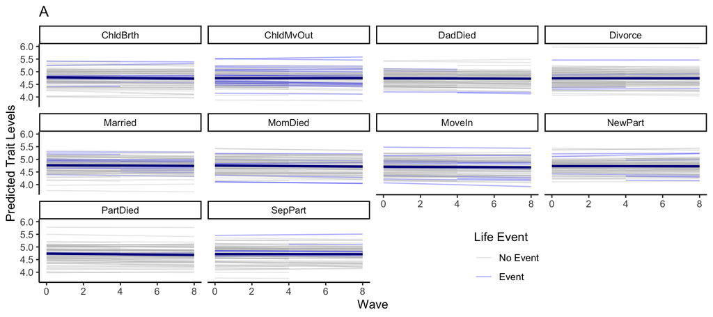

```r
soep_pred <- soep_pred |>
  mutate(p = map2(data, trait, spag_plot_fun))

soep_pred$p[[1]]
```

# Wrap-Up

## Wrap-Up

- Today’s goal was to review the coding concepts we’ve used so far and ask you to apply them using a series of guided examples
- The biggest takeaway I wanted you to have is *chaining*, or how you can use `tidyverse` functions in chains to accomplish a bunch of goals simultaneously
- We cleaned, composited, and ran 50 models across thousands of people, including predictions and tables in less than 100 lines of code. Just doing the models, `tidy()`, and `predict()` parts of that alone would have been 150 lines of code and introduced huge opportunities for errors!

# Appendix

## Full Code

### Data

```r
# load the codebook
(codebook <- read_csv("week6-codebook.csv") |>
    mutate(old_name = str_to_lower(old_name)))

old.names <- codebook$old_name # get old column names
new.names <- codebook$new_name # get new column names
soep <- read_csv("week6-data.csv") |>
    select(all_of(old.names))
```

#### Pivot Long

```r
soep_long <- soep |>
  setNames(new.names) |>
  pivot_longer(
    cols = c(-starts_with("Proc"), -starts_with("Dem"))
    , names_to = c("category",  "label",    "item_name",    "year")
    , names_pattern = "(.*)_(.*)_(.*)_(.*)"
    , values_to = "value"
    , values_drop_na = T
  ) |> mutate(year = as.numeric(year))
soep_long
```

#### Recode and Composite

```r
soep_big5 <- soep_long |>
  filter(category == "big5") |>
  mutate(value = mapvalues(value, seq(-8,0), rep(NA, 9))) |>
  drop_na(value) |>
  group_by(Proc_SID, label, year) |>
  summarize(value = mean(value)) |>
  ungroup()

soep_le <- soep_long |>
  filter(category == "le") |>
  mutate(value = mapvalues(value, seq(-8,1), c(rep(NA, 6), 0, NA, NA, 1))) |>
  drop_na(value) |>
  group_by(Proc_SID, label) |>
  summarize(value = sum(value)) |>
  ungroup()

soep_clean <- soep_big5 |>
  rename(trait = label, p_value = value) |>
  inner_join(
    soep_le |>
      rename(le = label, le_value = value)
  )
```

### Models

```r
soep_nested <- soep_clean |>
  group_by(trait, le) |>
  nest() |>
  ungroup()

lmer_fun <- function(d){
  d <- d |>
    mutate(wave = year - 2005) |>
    group_by(Proc_SID) |>
    filter(n() > 1)
  m <- lmer(p_value ~ wave + le_value + le_value:wave + (1 + wave | Proc_SID), data = d)
  return(m)
}

soep_nested <- soep_nested |>
  mutate(model = map(data, lmer_fun))
soep_nested
```

### Results

#### Tables

```r
nslopes_fun <- function(m) summary(m)$ngrps

soep_nested <- soep_nested |>
  mutate(npeople = map_int(model, nslopes_fun))
soep_nested

soep_nested <- soep_nested |>
  mutate(tidy = map(model, broom.mixed::tidy, conf.int = T))

soep_tab <- soep_nested |>
  select(-data, -model) |>
  unnest(tidy) |>
  filter(effect == "fixed" & grepl(":", term)) |>
  mutate(across(c(estimate, conf.low, conf.high), \(x) round(x, 2))) |>
  select(trait, le, estimate, conf.low, conf.high) |>
  pivot_wider(
    names_from = "trait"
    , names_glue = "{trait}_{.value}"
    , values_from = c(estimate, conf.low, conf.high)
  )
soep_tab
```

#### Model Predictions

```r
pred_fun <- function(m){
  d <- m@frame |>
      select(-p_value) |>
      distinct()
  bind_cols(d, pred = predict(m, newdata = d))
}

soep_nested <- soep_nested |>
  mutate(pred = map(model, pred_fun))
soep_nested

soep_pred <- soep_nested |>
  select(-data, -model, -tidy) |>
  unnest(pred) |>
  group_by(trait) |>
  nest() |>
  ungroup()
soep_pred

spag_plot_fun <- function(d, trait){
  set.seed(6)
  d |>
    group_by(le) |>
    nest() |>
    mutate(data = map(data, ~filter(., Proc_SID %in% sample(unique(.$Proc_SID), 100)))) |>
    unnest(data) |>
    ungroup() |>
    mutate(le_value = ifelse(le_value > 1, 1, le_value)) |>
    ggplot(aes(x = wave, y = pred)) +
      geom_line(aes(group = Proc_SID, color = factor(le_value)), alpha = .3) +
      geom_smooth(method = "lm", se = F, color = "darkblue") +
      scale_color_manual(values = c("grey", "blue"), labels = c("No Event", "Event")) +
      labs(x = "Wave", y = "Predicted Trait Levels", color = "Life Event", title = trait) +
      facet_wrap(~le) +
      theme_classic() +
      theme(legend.position = c(.7, .1))
}

soep_pred <- soep_pred |>
  mutate(p = map2(data, trait, spag_plot_fun))

soep_pred$p[[1]]
```